# 07 Autoencoder Incremental Value Analysis

This notebook evaluates whether the Autoencoder anomaly detector adds useful information beyond the supervised Random Forest model. Since the Random Forest already performs very strongly on PaySim, the Autoencoder should only be considered useful if it captures fraud cases missed by the supervised model without introducing excessive additional false positives.

The goal is not to prove that the Autoencoder outperforms the Random Forest. Instead, the goal is to test whether the Autoencoder provides a complementary anomaly signal.

If the Autoencoder does not capture additional fraud beyond Random Forest, it should be treated only as an experimental monitoring signal rather than a hard decision rule.

**Main research question:** Does the Autoencoder capture fraudulent transactions that the supervised Random Forest model misses?

## 1. Import Libraries and Project Modules

```python
import json
import sys
from pathlib import Path

import joblib
import numpy as np
import pandas as pd
import matplotlib.pyplot as plt
from scipy import sparse
from IPython.display import display, Markdown

from sklearn.metrics import (
    accuracy_score,
    precision_score,
    recall_score,
    f1_score,
    roc_auc_score,
    average_precision_score,
    confusion_matrix,
)
from sklearn.model_selection import train_test_split

PROJECT_ROOT = Path.cwd().parent if Path.cwd().name == "notebooks" else Path.cwd()
if str(PROJECT_ROOT) not in sys.path:
    sys.path.insert(0, str(PROJECT_ROOT))

from src.preprocessing import (
    load_paysim_data,
    create_engineered_features,
    prepare_features_and_target,
)

from src.train_autoencoder import (
    load_autoencoder_artifacts,
    calculate_reconstruction_errors,
)

RANDOM_STATE = 42
```

## 2. Define Paths

The notebook loads saved model artifacts only. It does not retrain Random Forest or Autoencoder models.

```python
DATA_PATH = PROJECT_ROOT / "data" / "raw" / "PS_20174392719_1491204439457_log.csv"
DATA_FALLBACK_PATH = PROJECT_ROOT / "data" / "raw" / "financial" / "paysim.csv"

SUPERVISED_MODEL_PATH = PROJECT_ROOT / "models" / "ml" / "final_supervised_model.pkl"

AUTOENCODER_MODEL_PATH = PROJECT_ROOT / "models" / "autoencoder" / "autoencoder_model.keras"
AUTOENCODER_PREPROCESSOR_PATH = PROJECT_ROOT / "models" / "autoencoder" / "autoencoder_preprocessor.pkl"
AUTOENCODER_THRESHOLD_PATH = PROJECT_ROOT / "models" / "autoencoder" / "autoencoder_threshold.json"
AUTOENCODER_RECONSTRUCTION_ERRORS_PATH = REPORTS_DIR / "autoencoder_test_reconstruction_errors.csv" if "REPORTS_DIR" in globals() else PROJECT_ROOT / "reports" / "autoencoder_test_reconstruction_errors.csv"

REPORTS_DIR = PROJECT_ROOT / "reports"
REPORTS_DIR.mkdir(parents=True, exist_ok=True)
AUTOENCODER_RECONSTRUCTION_ERRORS_PATH = REPORTS_DIR / "autoencoder_test_reconstruction_errors.csv"

if not DATA_PATH.exists():
    if DATA_FALLBACK_PATH.exists():
        print(f"Requested DATA_PATH not found: {DATA_PATH}")
        print(f"Using explicit project fallback path: {DATA_FALLBACK_PATH}")
        DATA_PATH = DATA_FALLBACK_PATH
    else:
        raise FileNotFoundError(f"PaySim dataset not found at {DATA_PATH} or {DATA_FALLBACK_PATH}")

required_artifacts = {
    "final supervised model": SUPERVISED_MODEL_PATH,
    "Autoencoder threshold metadata": AUTOENCODER_THRESHOLD_PATH,
}

for artifact_name, artifact_path in required_artifacts.items():
    if not artifact_path.exists():
        if artifact_name == "final supervised model":
            raise FileNotFoundError(
                f"Missing {artifact_name}: {artifact_path}. "
                "Please confirm the actual final supervised model filename from notebook 03."
            )
        raise FileNotFoundError(f"Missing {artifact_name}: {artifact_path}")

if not AUTOENCODER_MODEL_PATH.exists() or not AUTOENCODER_PREPROCESSOR_PATH.exists():
    print("Warning: Autoencoder model/preprocessor artifact is missing.")
    print("The notebook can still use saved reconstruction errors if available.")

if not AUTOENCODER_RECONSTRUCTION_ERRORS_PATH.exists():
    print(f"Warning: saved Autoencoder reconstruction error file not found: {AUTOENCODER_RECONSTRUCTION_ERRORS_PATH}")

print(f"Dataset path: {DATA_PATH}")
print(f"Supervised model path: {SUPERVISED_MODEL_PATH}")
print(f"Autoencoder model path: {AUTOENCODER_MODEL_PATH}")
print(f"Autoencoder reconstruction errors path: {AUTOENCODER_RECONSTRUCTION_ERRORS_PATH}")
print(f"Reports directory: {REPORTS_DIR}")
```

```
Requested DATA_PATH not found: D:\cs s1 26\基于深度学习的交易欺诈检测与智能风控系统\transaction-fraud-detection-system\data\raw\PS_20174392719_1491204439457_log.csv
Using explicit project fallback path: D:\cs s1 26\基于深度学习的交易欺诈检测与智能风控系统\transaction-fraud-detection-system\data\raw\financial\paysim.csv
Dataset path: D:\cs s1 26\基于深度学习的交易欺诈检测与智能风控系统\transaction-fraud-detection-system\data\raw\financial\paysim.csv
Supervised model path: D:\cs s1 26\基于深度学习的交易欺诈检测与智能风控系统\transaction-fraud-detection-system\models\ml\final_supervised_model.pkl
Autoencoder model path: D:\cs s1 26\基于深度学习的交易欺诈检测与智能风控系统\transaction-fraud-detection-system\models\autoencoder\autoencoder_model.keras
Autoencoder reconstruction errors path: D:\cs s1 26\基于深度学习的交易欺诈检测与智能风控系统\transaction-fraud-detection-system\reports\autoencoder_test_reconstruction_errors.csv
Reports directory: D:\cs s1 26\基于深度学习的交易欺诈检测与智能风控系统\transaction-fraud-detection-system\reports
```

## 3. Recreate the Same Train / Validation / Test Split

The split logic matches notebooks 03 and 04 so that Random Forest and Autoencoder predictions are compared on the same holdout test set.

```python
df = load_paysim_data(DATA_PATH)
df = create_engineered_features(df)
X, y = prepare_features_and_target(df)

X_trainval_full, X_test, y_trainval_full, y_test = train_test_split(
    X,
    y,
    test_size=0.2,
    stratify=y,
    random_state=RANDOM_STATE,
)

X_train_full, X_val, y_train_full, y_val = train_test_split(
    X_trainval_full,
    y_trainval_full,
    test_size=0.25,
    stratify=y_trainval_full,
    random_state=RANDOM_STATE,
)

print(f"X_test shape: {X_test.shape}")
print(f"y_test fraud count: {int(y_test.sum())}")
print(f"y_test fraud rate: {y_test.mean():.6f}")
```

```
X_test shape: (1272524, 16)
y_test fraud count: 1643
y_test fraud rate: 0.001291
```

## 4. Load Final Supervised Random Forest Model

The saved final supervised model from notebook 03 is evaluated on the recreated test set.

```python
def safe_divide(numerator, denominator):
    return numerator / denominator if denominator else np.nan


def evaluate_binary_predictions(y_true, y_pred, score=None, model_name="Model"):
    tn, fp, fn, tp = confusion_matrix(y_true, y_pred, labels=[0, 1]).ravel()

    metrics = {
        "model": model_name,
        "accuracy": accuracy_score(y_true, y_pred),
        "precision": precision_score(y_true, y_pred, zero_division=0),
        "recall": recall_score(y_true, y_pred, zero_division=0),
        "f1": f1_score(y_true, y_pred, zero_division=0),
        "tn": tn,
        "fp": fp,
        "fn": fn,
        "tp": tp,
    }

    if score is not None:
        try:
            metrics["roc_auc"] = roc_auc_score(y_true, score)
        except ValueError:
            metrics["roc_auc"] = np.nan
        try:
            metrics["pr_auc"] = average_precision_score(y_true, score)
        except ValueError:
            metrics["pr_auc"] = np.nan

    return metrics


final_supervised_model = joblib.load(SUPERVISED_MODEL_PATH)

rf_pred = final_supervised_model.predict(X_test)
rf_proba = None
if hasattr(final_supervised_model, "predict_proba"):
    rf_proba = final_supervised_model.predict_proba(X_test)[:, 1]
else:
    print("The supervised model does not expose predict_proba; ROC-AUC and PR-AUC will be skipped.")

rf_metrics = evaluate_binary_predictions(
    y_test,
    rf_pred,
    score=rf_proba,
    model_name="Random Forest",
)
rf_metrics_df = pd.DataFrame([rf_metrics])
rf_metrics_df
```

[output not shown]

|  | model | accuracy | precision | recall | f1 | tn | fp | fn | tp | roc_auc | pr_auc |
| --- | --- | --- | --- | --- | --- | --- | --- | --- | --- | --- | --- |
| 0 | Random Forest | 0.999992 | 0.996353 | 0.997565 | 0.996959 | 1270875 | 6 | 4 | 1639 | 0.999978 | 0.998844 |

## 5. Load Autoencoder Artifacts

```python
autoencoder_model = None
autoencoder_preprocessor = None
loaded_autoencoder_artifacts = False

try:
    autoencoder_model, autoencoder_preprocessor, threshold_metadata = load_autoencoder_artifacts(
        model_path=AUTOENCODER_MODEL_PATH,
        preprocessor_path=AUTOENCODER_PREPROCESSOR_PATH,
        threshold_path=AUTOENCODER_THRESHOLD_PATH,
    )
    loaded_autoencoder_artifacts = True
    print("Loaded Autoencoder model and preprocessor artifacts.")
except ImportError as error:
    print("Warning: could not load the Keras Autoencoder model in this environment.")
    print(error)
    print("Falling back to saved Autoencoder test reconstruction errors from notebook 04.")
    with open(AUTOENCODER_THRESHOLD_PATH, "r", encoding="utf-8") as file:
        threshold_metadata = json.load(file)

if not loaded_autoencoder_artifacts and not AUTOENCODER_RECONSTRUCTION_ERRORS_PATH.exists():
    raise FileNotFoundError(
        "TensorFlow is unavailable and saved Autoencoder reconstruction errors were not found. "
        "Install TensorFlow or rerun notebook 04 to generate reports/autoencoder_test_reconstruction_errors.csv."
    )

ae_threshold = threshold_metadata["threshold"]

metadata_summary = {
    "threshold": threshold_metadata.get("threshold"),
    "selected_percentile": threshold_metadata.get("validation_metrics", {}).get("selected_percentile"),
    "config": threshold_metadata.get("config", {}).get("config_name"),
    "max_review_rate": threshold_metadata.get("validation_metrics", {}).get("max_review_rate"),
    "min_precision": threshold_metadata.get("validation_metrics", {}).get("min_precision"),
    "selection_policy": threshold_metadata.get("validation_metrics", {}).get("selection_policy"),
    "loaded_keras_artifact": loaded_autoencoder_artifacts,
}

pd.DataFrame([metadata_summary])
```

|  | threshold | selected_percentile | config | max_review_rate | min_precision | selection_policy | loaded_keras_artifact |
| --- | --- | --- | --- | --- | --- | --- | --- |
| 0 | 0.408394 | 99.05 | small_autoencoder | 0.01 | 0.05 | maximize_recall_under_review_budget | False |

## 6. Generate Autoencoder Predictions on the Same Test Set

```python
if loaded_autoencoder_artifacts:
    X_test_ae = autoencoder_preprocessor.transform(X_test)
    if sparse.issparse(X_test_ae):
        X_test_ae = X_test_ae.toarray()
    else:
        X_test_ae = np.asarray(X_test_ae)

    X_test_ae = X_test_ae.astype("float32")

    ae_reconstruction_errors = calculate_reconstruction_errors(autoencoder_model, X_test_ae)
    ae_pred = (ae_reconstruction_errors > ae_threshold).astype(int)
else:
    saved_ae_errors_df = pd.read_csv(AUTOENCODER_RECONSTRUCTION_ERRORS_PATH)
    if len(saved_ae_errors_df) != len(y_test):
        raise ValueError(
            "Saved Autoencoder reconstruction error file length does not match recreated test set length."
        )
    if "isFraud" in saved_ae_errors_df.columns:
        saved_y = saved_ae_errors_df["isFraud"].to_numpy()
        current_y = y_test.to_numpy() if hasattr(y_test, "to_numpy") else np.asarray(y_test)
        if not np.array_equal(saved_y, current_y):
            print("Warning: saved Autoencoder isFraud column does not exactly match recreated y_test order.")
    ae_reconstruction_errors = saved_ae_errors_df["reconstruction_error"].to_numpy()
    if "is_anomaly_predicted" in saved_ae_errors_df.columns:
        ae_pred = saved_ae_errors_df["is_anomaly_predicted"].astype(int).to_numpy()
    else:
        ae_pred = (ae_reconstruction_errors > ae_threshold).astype(int)


ae_metrics = evaluate_binary_predictions(
    y_test,
    ae_pred,
    score=ae_reconstruction_errors,
    model_name="Autoencoder",
)
ae_metrics["predicted_anomaly_rate"] = ae_pred.mean()
ae_metrics_df = pd.DataFrame([ae_metrics])
ae_metrics_df
```

|  | model | accuracy | precision | recall | f1 | tn | fp | fn | tp | roc_auc | pr_auc | predicted_anomaly_rate |
| --- | --- | --- | --- | --- | --- | --- | --- | --- | --- | --- | --- | --- |
| 0 | Autoencoder | 0.990469 | 0.068548 | 0.506999 | 0.120768 | 1259562 | 11319 | 810 | 833 | 0.938367 | 0.269921 | 0.00955 |

## Consistency Check with Saved Notebook 03 and Notebook 04 Results

This section verifies that notebook 07 is using the same test set, same saved models, and same artifacts as notebook 03 and notebook 04.

If these metrics differ substantially, it may indicate that notebook 07 is not using the same test split or model artifacts as notebooks 03 and 04. Small floating-point differences are acceptable.

```python
def load_saved_metrics_if_exists(path, report_name):
    if path.exists():
        print(f"Loaded saved {report_name}: {path}")
        return pd.read_csv(path)
    print(f"Warning: saved {report_name} not found at {path}")
    return None


def get_metric_from_row(row, metric):
    aliases = {
        "pr_auc": ["pr_auc", "average_precision"],
        "roc_auc": ["roc_auc"],
        "precision": ["precision"],
        "recall": ["recall"],
        "f1": ["f1", "f1_score"],
        "tn": ["tn"],
        "fp": ["fp"],
        "fn": ["fn"],
        "tp": ["tp"],
    }
    for column in aliases.get(metric, [metric]):
        if column in row.index:
            return row[column]
    return np.nan


def create_consistency_check_df(notebook_metrics, saved_metrics_df, metrics_to_compare):
    if saved_metrics_df is None or saved_metrics_df.empty:
        return None

    saved_row = saved_metrics_df.iloc[0]
    rows = []
    for metric in metrics_to_compare:
        notebook_value = notebook_metrics.get(metric, np.nan)
        saved_value = get_metric_from_row(saved_row, metric)
        rows.append(
            {
                "metric": metric,
                "notebook07_value": notebook_value,
                "saved_report_value": saved_value,
                "absolute_difference": abs(notebook_value - saved_value)
                if pd.notna(notebook_value) and pd.notna(saved_value)
                else np.nan,
            }
        )
    return pd.DataFrame(rows)


RF_SAVED_REPORT_PATH = REPORTS_DIR / "final_supervised_test_evaluation.csv"
AE_SAVED_REPORT_PATH = REPORTS_DIR / "autoencoder_test_evaluation.csv"

saved_rf_metrics_df = load_saved_metrics_if_exists(
    RF_SAVED_REPORT_PATH,
    "notebook 03 final supervised test evaluation",
)
saved_ae_metrics_df = load_saved_metrics_if_exists(
    AE_SAVED_REPORT_PATH,
    "notebook 04 Autoencoder test evaluation",
)

consistency_metrics = ["precision", "recall", "f1", "roc_auc", "pr_auc", "tn", "fp", "fn", "tp"]

rf_consistency_check_df = create_consistency_check_df(
    rf_metrics,
    saved_rf_metrics_df,
    consistency_metrics,
)
ae_consistency_check_df = create_consistency_check_df(
    ae_metrics,
    saved_ae_metrics_df,
    consistency_metrics,
)

if rf_consistency_check_df is not None:
    display(rf_consistency_check_df)
else:
    print("Random Forest consistency check skipped because saved report is unavailable.")

if ae_consistency_check_df is not None:
    display(ae_consistency_check_df)
else:
    print("Autoencoder consistency check skipped because saved report is unavailable.")
```

```
Loaded saved notebook 03 final supervised test evaluation: D:\cs s1 26\基于深度学习的交易欺诈检测与智能风控系统\transaction-fraud-detection-system\reports\final_supervised_test_evaluation.csv
Loaded saved notebook 04 Autoencoder test evaluation: D:\cs s1 26\基于深度学习的交易欺诈检测与智能风控系统\transaction-fraud-detection-system\reports\autoencoder_test_evaluation.csv
```

|  | metric | notebook07_value | saved_report_value | absolute_difference |
| --- | --- | --- | --- | --- |
| 0 | precision | 9.963526e-01 | 9.963526e-01 | 0.000000e+00 |
| 1 | recall | 9.975654e-01 | 9.975654e-01 | 1.110223e-16 |
| 2 | f1 | 9.969586e-01 | 9.969586e-01 | 0.000000e+00 |
| 3 | roc_auc | 9.999776e-01 | 9.999776e-01 | 0.000000e+00 |
| 4 | pr_auc | 9.988442e-01 | 9.988442e-01 | 1.110223e-16 |
| 5 | tn | 1.270875e+06 | 1.270875e+06 | 0.000000e+00 |
| 6 | fp | 6.000000e+00 | 6.000000e+00 | 0.000000e+00 |
| 7 | fn | 4.000000e+00 | 4.000000e+00 | 0.000000e+00 |
| 8 | tp | 1.639000e+03 | 1.639000e+03 | 0.000000e+00 |

|  | metric | notebook07_value | saved_report_value | absolute_difference |
| --- | --- | --- | --- | --- |
| 0 | precision | 6.854839e-02 | 6.854839e-02 | 8.326673e-17 |
| 1 | recall | 5.069994e-01 | 5.069994e-01 | 0.000000e+00 |
| 2 | f1 | 1.207684e-01 | 1.207684e-01 | 5.551115e-17 |
| 3 | roc_auc | 9.383670e-01 | 9.383670e-01 | 0.000000e+00 |
| 4 | pr_auc | 2.699210e-01 | 2.699210e-01 | 0.000000e+00 |
| 5 | tn | 1.259562e+06 | 1.259562e+06 | 0.000000e+00 |
| 6 | fp | 1.131900e+04 | 1.131900e+04 | 0.000000e+00 |
| 7 | fn | 8.100000e+02 | 8.100000e+02 | 0.000000e+00 |
| 8 | tp | 8.330000e+02 | 8.330000e+02 | 0.000000e+00 |

## 7. Create Combined Prediction DataFrame

```python
comparison_df = pd.DataFrame(
    {
        "original_index": X_test.index,
        "isFraud": y_test.to_numpy() if hasattr(y_test, "to_numpy") else np.asarray(y_test),
        "rf_pred": rf_pred,
        "ae_pred": ae_pred,
        "ae_reconstruction_error": ae_reconstruction_errors,
    }
)

if rf_proba is not None:
    comparison_df["rf_fraud_probability"] = rf_proba

candidate_feature_cols = [
    "type",
    "amount",
    "oldbalanceOrg",
    "newbalanceOrig",
    "oldbalanceDest",
    "newbalanceDest",
    "is_high_risk_type",
    "orig_balance_error",
    "dest_balance_error",
    "amount_to_oldbalanceOrg_ratio_clipped",
    "is_orig_balance_drained",
]

for col in candidate_feature_cols:
    if col in X_test.columns:
        comparison_df[col] = X_test[col].values

comparison_df["rf_correct"] = comparison_df["rf_pred"] == comparison_df["isFraud"]
comparison_df["ae_correct"] = comparison_df["ae_pred"] == comparison_df["isFraud"]

comparison_df["rf_missed_fraud"] = (
    (comparison_df["isFraud"] == 1) & (comparison_df["rf_pred"] == 0)
)
comparison_df["ae_captured_fraud"] = (
    (comparison_df["isFraud"] == 1) & (comparison_df["ae_pred"] == 1)
)
comparison_df["ae_only_fraud"] = (
    (comparison_df["isFraud"] == 1)
    & (comparison_df["rf_pred"] == 0)
    & (comparison_df["ae_pred"] == 1)
)
comparison_df["ae_only_false_positive"] = (
    (comparison_df["isFraud"] == 0)
    & (comparison_df["rf_pred"] == 0)
    & (comparison_df["ae_pred"] == 1)
)

comparison_df.head()
```

|  | original_index | isFraud | rf_pred | ae_pred | ae_reconstruction_error | rf_fraud_probability | type | amount | oldbalanceOrg | newbalanceOrig | ... | orig_balance_error | dest_balance_error | amount_to_oldbalanceOrg_ratio_clipped | is_orig_balance_drained | rf_correct | ae_correct | rf_missed_fraud | ae_captured_fraud | ae_only_fraud | ae_only_false_positive |
| --- | --- | --- | --- | --- | --- | --- | --- | --- | --- | --- | --- | --- | --- | --- | --- | --- | --- | --- | --- | --- | --- |
| 0 | 4051353 | 0 | 0 | 0 | 0.038276 | 0.000000 | TRANSFER | 890577.21 | 218.00 | 0.00 | ... | -890359.21 | 0.000000e+00 | 100.000000 | 1 | True | True | False | False | False | False |
| 1 | 5746321 | 0 | 0 | 0 | 0.012702 | 0.000000 | CASH_IN | 97734.24 | 2096258.84 | 2193993.08 | ... | -195468.48 | -1.954685e+05 | 0.046623 | 0 | True | True | False | False | False | False |
| 2 | 6361797 | 0 | 0 | 0 | 0.070772 | 0.000000 | PAYMENT | 5907.41 | 315.00 | 0.00 | ... | -5592.41 | -5.907410e+03 | 18.694335 | 1 | True | True | False | False | False | False |
| 3 | 2247309 | 0 | 0 | 0 | 0.009151 | 0.000019 | CASH_OUT | 187696.30 | 11057.00 | 0.00 | ... | -176639.30 | 5.820766e-11 | 16.973802 | 1 | True | True | False | False | False | False |
| 4 | 4692207 | 0 | 0 | 0 | 0.003290 | 0.000165 | CASH_OUT | 82646.52 | 0.00 | 0.00 | ... | -82646.52 | -1.018634e-10 | 100.000000 | 1 | True | True | False | False | False | False |

5 rows × 23 columns

## 8. Incremental Value Summary

This section measures whether Autoencoder flags fraud cases that Random Forest misses.

```python
total_fraud = int((comparison_df["isFraud"] == 1).sum())
rf_true_positives = int(((comparison_df["isFraud"] == 1) & (comparison_df["rf_pred"] == 1)).sum())
rf_false_negatives = int(((comparison_df["isFraud"] == 1) & (comparison_df["rf_pred"] == 0)).sum())
ae_true_positives = int(((comparison_df["isFraud"] == 1) & (comparison_df["ae_pred"] == 1)).sum())
ae_false_negatives = int(((comparison_df["isFraud"] == 1) & (comparison_df["ae_pred"] == 0)).sum())
fraud_captured_by_both = int(((comparison_df["isFraud"] == 1) & (comparison_df["rf_pred"] == 1) & (comparison_df["ae_pred"] == 1)).sum())
fraud_captured_only_by_rf = int(((comparison_df["isFraud"] == 1) & (comparison_df["rf_pred"] == 1) & (comparison_df["ae_pred"] == 0)).sum())
fraud_captured_only_by_ae = int(comparison_df["ae_only_fraud"].sum())
fraud_missed_by_both = int(((comparison_df["isFraud"] == 1) & (comparison_df["rf_pred"] == 0) & (comparison_df["ae_pred"] == 0)).sum())
ae_captured_rf_false_negatives = fraud_captured_only_by_ae
ae_only_false_positive = int(comparison_df["ae_only_false_positive"].sum())
additional_review_volume = ae_only_false_positive + fraud_captured_only_by_ae
incremental_recall_gain = safe_divide(fraud_captured_only_by_ae, total_fraud)
ae_incremental_precision = safe_divide(
    fraud_captured_only_by_ae,
    fraud_captured_only_by_ae + ae_only_false_positive,
)

incremental_summary_df = pd.DataFrame(
    [
        ("total_fraud_in_test", total_fraud),
        ("rf_true_positives", rf_true_positives),
        ("rf_false_negatives", rf_false_negatives),
        ("ae_true_positives", ae_true_positives),
        ("ae_false_negatives", ae_false_negatives),
        ("fraud_captured_by_both", fraud_captured_by_both),
        ("fraud_captured_only_by_rf", fraud_captured_only_by_rf),
        ("fraud_captured_only_by_ae", fraud_captured_only_by_ae),
        ("fraud_missed_by_both", fraud_missed_by_both),
        ("ae_captured_rf_false_negatives", ae_captured_rf_false_negatives),
        ("ae_only_false_positive", ae_only_false_positive),
        ("additional_review_volume_caused_by_ae_only_flags", additional_review_volume),
        ("incremental_recall_gain", incremental_recall_gain),
        ("additional_false_positive_cost", ae_only_false_positive),
        ("ae_incremental_precision", ae_incremental_precision),
    ],
    columns=["metric", "value"],
)

incremental_summary_df
```

|  | metric | value |
| --- | --- | --- |
| 0 | total_fraud_in_test | 1643.0 |
| 1 | rf_true_positives | 1639.0 |
| 2 | rf_false_negatives | 4.0 |
| 3 | ae_true_positives | 833.0 |
| 4 | ae_false_negatives | 810.0 |
| 5 | fraud_captured_by_both | 833.0 |
| 6 | fraud_captured_only_by_rf | 806.0 |
| 7 | fraud_captured_only_by_ae | 0.0 |
| 8 | fraud_missed_by_both | 4.0 |
| 9 | ae_captured_rf_false_negatives | 0.0 |
| 10 | ae_only_false_positive | 11318.0 |
| 11 | additional_review_volume_caused_by_ae_only_flags | 11318.0 |
| 12 | incremental_recall_gain | 0.0 |
| 13 | additional_false_positive_cost | 11318.0 |
| 14 | ae_incremental_precision | 0.0 |

## 9. Compare RF-Only, AE-Only, and RF OR AE

The OR rule is intentionally aggressive. It estimates the maximum possible fraud capture if Autoencoder were used as an additional hard review trigger. If recall improves only slightly while false positives increase sharply, Autoencoder should not be used as a hard OR-rule.

```python
combined_or_pred = ((rf_pred == 1) | (ae_pred == 1)).astype(int)

rf_only_metrics = evaluate_binary_predictions(y_test, rf_pred, model_name="Random Forest only")
ae_only_metrics = evaluate_binary_predictions(y_test, ae_pred, model_name="Autoencoder only")
combined_or_metrics = evaluate_binary_predictions(y_test, combined_or_pred, model_name="RF OR AE")

comparison_metrics_df = pd.DataFrame(
    [rf_only_metrics, ae_only_metrics, combined_or_metrics]
)
comparison_metrics_df["predicted_positive_count"] = [
    int(np.sum(rf_pred == 1)),
    int(np.sum(ae_pred == 1)),
    int(np.sum(combined_or_pred == 1)),
]
comparison_metrics_df["predicted_positive_rate"] = comparison_metrics_df[
    "predicted_positive_count"
] / len(y_test)

rf_fp = int(rf_only_metrics["fp"])
rf_recall = rf_only_metrics["recall"]
combined_or_fp = int(combined_or_metrics["fp"])
combined_or_recall = combined_or_metrics["recall"]

comparison_metrics_df["fp_increase_vs_rf"] = np.nan
comparison_metrics_df["recall_gain_vs_rf"] = np.nan
comparison_metrics_df.loc[
    comparison_metrics_df["model"] == "Random Forest only",
    ["fp_increase_vs_rf", "recall_gain_vs_rf"],
] = [0, 0]
comparison_metrics_df.loc[
    comparison_metrics_df["model"] == "RF OR AE",
    "fp_increase_vs_rf",
] = combined_or_fp - rf_fp
comparison_metrics_df.loc[
    comparison_metrics_df["model"] == "RF OR AE",
    "recall_gain_vs_rf",
] = combined_or_recall - rf_recall

comparison_metrics_df[
    [
        "model",
        "precision",
        "recall",
        "f1",
        "tn",
        "fp",
        "fn",
        "tp",
        "predicted_positive_count",
        "predicted_positive_rate",
        "fp_increase_vs_rf",
        "recall_gain_vs_rf",
    ]
]
```

|  | model | precision | recall | f1 | tn | fp | fn | tp | predicted_positive_count | predicted_positive_rate | fp_increase_vs_rf | recall_gain_vs_rf |
| --- | --- | --- | --- | --- | --- | --- | --- | --- | --- | --- | --- | --- |
| 0 | Random Forest only | 0.996353 | 0.997565 | 0.996959 | 1270875 | 6 | 4 | 1639 | 1645 | 0.001293 | 0.0 | 0.0 |
| 1 | Autoencoder only | 0.068548 | 0.506999 | 0.120768 | 1259562 | 11319 | 810 | 833 | 12152 | 0.009550 | NaN | NaN |
| 2 | RF OR AE | 0.126437 | 0.997565 | 0.224428 | 1259557 | 11324 | 4 | 1639 | 12963 | 0.010187 | 11318.0 | 0.0 |

## 10. Analyze Random Forest False Negatives

This is the key test of whether Autoencoder adds value beyond the supervised model.

```python
rf_fn_df = comparison_df[comparison_df["rf_missed_fraud"]].copy()
rf_fn_df["ae_threshold"] = ae_threshold

num_rf_false_negatives = len(rf_fn_df)
num_rf_fn_captured_by_ae = int((rf_fn_df["ae_pred"] == 1).sum()) if num_rf_false_negatives else 0
num_rf_fn_still_missed_by_ae = int((rf_fn_df["ae_pred"] == 0).sum()) if num_rf_false_negatives else 0

print(f"Number of RF false negatives: {num_rf_false_negatives}")
print(f"RF false negatives captured by AE: {num_rf_fn_captured_by_ae}")
print(f"RF false negatives still missed by AE: {num_rf_fn_still_missed_by_ae}")

if rf_fn_df.empty:
    print("Random Forest has no false negatives on this recreated test set.")
else:
    fn_display_columns = [
        "original_index",
        "isFraud",
        "rf_pred",
        "ae_pred",
        "ae_reconstruction_error",
        "ae_threshold",
    ]
    if "rf_fraud_probability" in rf_fn_df.columns:
        fn_display_columns.insert(3, "rf_fraud_probability")

    optional_columns = [
        "type",
        "amount",
        "oldbalanceOrg",
        "newbalanceOrig",
        "oldbalanceDest",
        "newbalanceDest",
        "orig_balance_error",
        "dest_balance_error",
        "is_high_risk_type",
        "is_orig_balance_drained",
    ]
    fn_display_columns.extend([col for col in optional_columns if col in rf_fn_df.columns])

    display(rf_fn_df[fn_display_columns])
```

```
Number of RF false negatives: 4
RF false negatives captured by AE: 0
RF false negatives still missed by AE: 4
```

|  | original_index | isFraud | rf_pred | rf_fraud_probability | ae_pred | ae_reconstruction_error | ae_threshold | type | amount | oldbalanceOrg | newbalanceOrig | oldbalanceDest | newbalanceDest | orig_balance_error | dest_balance_error | is_high_risk_type | is_orig_balance_drained |
| --- | --- | --- | --- | --- | --- | --- | --- | --- | --- | --- | --- | --- | --- | --- | --- | --- | --- |
| 349729 | 77745 | 1 | 0 | 0.327228 | 0 | 0.017940 | 0.408394 | CASH_OUT | 277970.88 | 0.00 | 0.0 | 0.00 | 277970.88 | -277970.88 | 0.000000e+00 | 1 | 1 |
| 466829 | 543928 | 1 | 0 | 0.004380 | 0 | 0.017412 | 0.408394 | CASH_OUT | 23292.30 | 0.00 | 0.0 | 392364.62 | 415656.92 | -23292.30 | -1.091394e-11 | 1 | 1 |
| 471593 | 217978 | 1 | 0 | 0.012639 | 0 | 0.175137 | 0.408394 | TRANSFER | 123194.95 | 79466.45 | 0.0 | 535933.16 | 263908.84 | -43728.50 | -3.952193e+05 | 1 | 1 |
| 1071189 | 14861 | 1 | 0 | 0.362666 | 0 | 0.014391 | 0.408394 | CASH_OUT | 181728.11 | 0.00 | 0.0 | 11397.00 | 184477.77 | -181728.11 | -8.647340e+03 | 1 | 1 |

## 11. Visualize Overlap

These plots inspect true-positive overlap, false-positive cost, and the relationship between supervised fraud probability and Autoencoder reconstruction error.

If the number of Random Forest false negatives is very small, plots involving RF false negatives should be treated as diagnostic only and should not be over-interpreted. The exact table of missed cases is more important than the histogram.

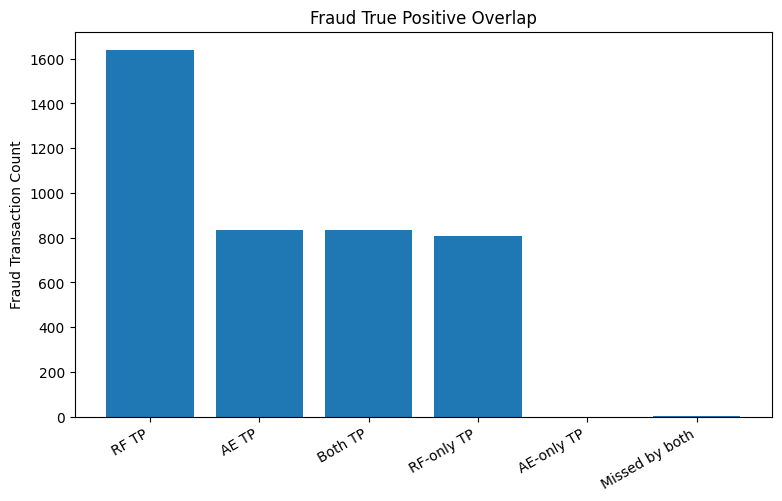

```python
tp_overlap_values = pd.Series(
    {
        "RF TP": rf_true_positives,
        "AE TP": ae_true_positives,
        "Both TP": fraud_captured_by_both,
        "RF-only TP": fraud_captured_only_by_rf,
        "AE-only TP": fraud_captured_only_by_ae,
        "Missed by both": fraud_missed_by_both,
    }
)

plt.figure(figsize=(9, 5))
plt.bar(tp_overlap_values.index, tp_overlap_values.values)
plt.title("Fraud True Positive Overlap")
plt.ylabel("Fraud Transaction Count")
plt.xticks(rotation=30, ha="right")
plt.show()
```

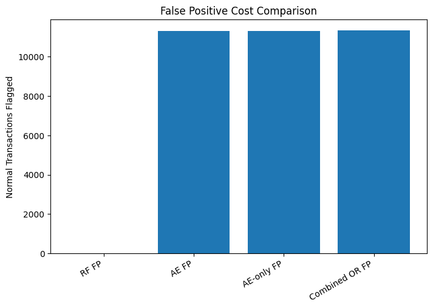

```python
ae_fp = int(((comparison_df["isFraud"] == 0) & (comparison_df["ae_pred"] == 1)).sum())

fp_values = pd.Series(
    {
        "RF FP": rf_fp,
        "AE FP": ae_fp,
        "AE-only FP": ae_only_false_positive,
        "Combined OR FP": combined_or_fp,
    }
)

plt.figure(figsize=(8, 5))
plt.bar(fp_values.index, fp_values.values)
plt.title("False Positive Cost Comparison")
plt.ylabel("Normal Transactions Flagged")
plt.xticks(rotation=30, ha="right")
plt.show()
```

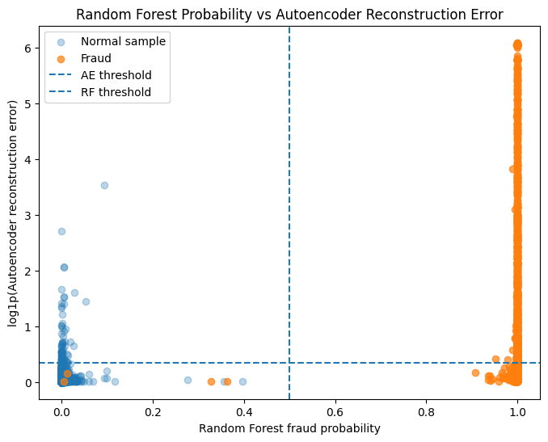

```python
if rf_proba is not None:
    normal_scatter_df = comparison_df[comparison_df["isFraud"] == 0].sample(
        n=min(10_000, int((comparison_df["isFraud"] == 0).sum())),
        random_state=RANDOM_STATE,
    )
    fraud_scatter_df = comparison_df[comparison_df["isFraud"] == 1]

    plt.figure(figsize=(8, 6))
    plt.scatter(
        normal_scatter_df["rf_fraud_probability"],
        np.log1p(normal_scatter_df["ae_reconstruction_error"]),
        alpha=0.3,
        label="Normal sample",
    )
    plt.scatter(
        fraud_scatter_df["rf_fraud_probability"],
        np.log1p(fraud_scatter_df["ae_reconstruction_error"]),
        alpha=0.7,
        label="Fraud",
    )
    plt.axhline(np.log1p(ae_threshold), linestyle="--", label="AE threshold")
    plt.axvline(0.5, linestyle="--", label="RF threshold")
    plt.xlabel("Random Forest fraud probability")
    plt.ylabel("log1p(Autoencoder reconstruction error)")
    plt.title("Random Forest Probability vs Autoencoder Reconstruction Error")
    plt.legend()
    plt.show()
else:
    print("Skipping scatter plot because RF fraud probabilities are unavailable.")
```

```
RF false negative count for histogram: 4
```

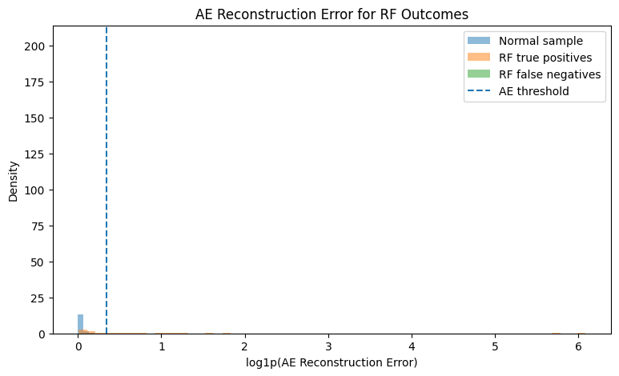

```python
rf_fn_errors = rf_fn_df["ae_reconstruction_error"] if len(rf_fn_df) > 0 else pd.Series(dtype=float)
rf_tp_errors = comparison_df.loc[
    (comparison_df["isFraud"] == 1) & (comparison_df["rf_pred"] == 1),
    "ae_reconstruction_error",
]
normal_error_sample = comparison_df.loc[comparison_df["isFraud"] == 0, "ae_reconstruction_error"].sample(
    n=min(50_000, int((comparison_df["isFraud"] == 0).sum())),
    random_state=RANDOM_STATE,
)

print(f"RF false negative count for histogram: {len(rf_fn_errors)}")

if len(rf_fn_errors) > 0:
    plt.figure(figsize=(9, 5))
    plt.hist(np.log1p(normal_error_sample), bins=60, alpha=0.5, density=True, label="Normal sample")
    if len(rf_tp_errors) > 0:
        plt.hist(np.log1p(rf_tp_errors), bins=60, alpha=0.5, density=True, label="RF true positives")
    plt.hist(np.log1p(rf_fn_errors), bins=60, alpha=0.5, density=True, label="RF false negatives")
    plt.axvline(np.log1p(ae_threshold), linestyle="--", label="AE threshold")
    plt.title("AE Reconstruction Error for RF Outcomes")
    plt.xlabel("log1p(AE Reconstruction Error)")
    plt.ylabel("Density")
    plt.legend()
    plt.show()
else:
    print("Skipping RF false negative histogram because there are no RF false negatives.")
```

## 12. Save Analysis Outputs

```python
incremental_summary_path = REPORTS_DIR / "autoencoder_incremental_value_summary.csv"
comparison_metrics_path = REPORTS_DIR / "rf_ae_comparison_metrics.csv"
predictions_path = REPORTS_DIR / "rf_ae_test_predictions.csv"
rf_consistency_path = REPORTS_DIR / "rf_consistency_check.csv"
ae_consistency_path = REPORTS_DIR / "ae_consistency_check.csv"

incremental_summary_df.to_csv(incremental_summary_path, index=False)
comparison_metrics_df.to_csv(comparison_metrics_path, index=False)

if rf_consistency_check_df is not None:
    rf_consistency_check_df.to_csv(rf_consistency_path, index=False)
if ae_consistency_check_df is not None:
    ae_consistency_check_df.to_csv(ae_consistency_path, index=False)

prediction_columns = [
    "isFraud",
    "rf_pred",
    "ae_pred",
    "ae_reconstruction_error",
    "ae_only_fraud",
    "ae_only_false_positive",
    "rf_missed_fraud",
]
if "rf_fraud_probability" in comparison_df.columns:
    prediction_columns.insert(3, "rf_fraud_probability")

prediction_export_df = comparison_df[prediction_columns]
chunk_size = 200_000
for start in range(0, len(prediction_export_df), chunk_size):
    end = min(start + chunk_size, len(prediction_export_df))
    prediction_export_df.iloc[start:end].to_csv(
        predictions_path,
        index=False,
        mode="w" if start == 0 else "a",
        header=start == 0,
    )
    print(f"Saved prediction rows {end}/{len(prediction_export_df)}")

print(f"Saved incremental summary to: {incremental_summary_path}")
print(f"Saved RF/AE comparison metrics to: {comparison_metrics_path}")
print(f"Saved test predictions to: {predictions_path}")
if rf_consistency_check_df is not None:
    print(f"Saved RF consistency check to: {rf_consistency_path}")
if ae_consistency_check_df is not None:
    print(f"Saved AE consistency check to: {ae_consistency_path}")
```

```
Saved prediction rows 200000/1272524
```

```
Saved prediction rows 400000/1272524
```

```
Saved prediction rows 600000/1272524
```

```
Saved prediction rows 800000/1272524
```

```
Saved prediction rows 1000000/1272524
```

```
Saved prediction rows 1200000/1272524
```

```
Saved prediction rows 1272524/1272524
Saved incremental summary to: D:\cs s1 26\基于深度学习的交易欺诈检测与智能风控系统\transaction-fraud-detection-system\reports\autoencoder_incremental_value_summary.csv
Saved RF/AE comparison metrics to: D:\cs s1 26\基于深度学习的交易欺诈检测与智能风控系统\transaction-fraud-detection-system\reports\rf_ae_comparison_metrics.csv
Saved test predictions to: D:\cs s1 26\基于深度学习的交易欺诈检测与智能风控系统\transaction-fraud-detection-system\reports\rf_ae_test_predictions.csv
Saved RF consistency check to: D:\cs s1 26\基于深度学习的交易欺诈检测与智能风控系统\transaction-fraud-detection-system\reports\rf_consistency_check.csv
Saved AE consistency check to: D:\cs s1 26\基于深度学习的交易欺诈检测与智能风控系统\transaction-fraud-detection-system\reports\ae_consistency_check.csv
```

## 13. Final Conclusion

The conclusion below is generated from the overlap analysis results. It should not force a positive interpretation.

```python
rf_or_ae_recall_gain = combined_or_recall - rf_recall
rf_or_ae_fp_increase = combined_or_fp - rf_fp

if rf_false_negatives == 0:
    conclusion = f"""
### Conclusion

Random Forest did not miss any fraud cases on this test set, so there are no missed fraud cases for Autoencoder to recover. Autoencoder may still provide an anomaly monitoring signal, but this test does not show incremental fraud-capture value beyond Random Forest.

Key results:
- RF false negatives: **{rf_false_negatives}**
- AE captured RF false negatives: **{ae_captured_rf_false_negatives}**
- AE-only fraud: **{fraud_captured_only_by_ae}**
- AE-only false positives: **{ae_only_false_positive}**
- AE incremental precision: **{ae_incremental_precision:.6f}**
- RF OR AE recall gain vs RF only: **{rf_or_ae_recall_gain:.6f}**
- RF OR AE false positive increase vs RF only: **{rf_or_ae_fp_increase}**

Recommendation: Autoencoder should not be used as a hard OR-rule based on this test. It can be retained as a soft anomaly score or experimental monitoring signal.
    """
elif ae_captured_rf_false_negatives == 0:
    conclusion = f"""
### Conclusion

Autoencoder did not capture any fraud cases missed by Random Forest. Although it detects some fraudulent transactions, those mostly overlap with fraud already captured by Random Forest. Therefore, Autoencoder should not be used as a hard OR-rule in the final system.

Key results:
- RF false negatives: **{rf_false_negatives}**
- AE captured RF false negatives: **{ae_captured_rf_false_negatives}**
- AE-only fraud: **{fraud_captured_only_by_ae}**
- AE-only false positives: **{ae_only_false_positive}**
- AE incremental precision: **{ae_incremental_precision:.6f}**
- RF OR AE recall gain vs RF only: **{rf_or_ae_recall_gain:.6f}**
- RF OR AE false positive increase vs RF only: **{rf_or_ae_fp_increase}**

Recommendation: Autoencoder should be treated as a soft anomaly score or experimental monitoring signal, not a hard review trigger.
    """
else:
    conclusion = f"""
### Conclusion

Autoencoder captured some fraud cases missed by Random Forest. However, this benefit must be weighed against the number of additional false positives introduced by AE-only flags. If AE-only false positives are very large relative to AE-only fraud, Autoencoder should be used only as a soft anomaly score or monitoring signal, not as a hard review trigger.

Key results:
- RF false negatives: **{rf_false_negatives}**
- AE captured RF false negatives: **{ae_captured_rf_false_negatives}**
- AE-only fraud: **{fraud_captured_only_by_ae}**
- AE-only false positives: **{ae_only_false_positive}**
- AE incremental precision: **{ae_incremental_precision:.6f}**
- RF OR AE recall gain vs RF only: **{rf_or_ae_recall_gain:.6f}**
- RF OR AE false positive increase vs RF only: **{rf_or_ae_fp_increase}**

Recommendation: Autoencoder may have limited complementary value, but it should be integrated cautiously as a soft anomaly score rather than a standalone hard OR-rule.
    """

display(Markdown(conclusion))
```

Conclusion

Autoencoder did not capture any fraud cases missed by Random Forest. Although it detects some fraudulent transactions, those mostly overlap with fraud already captured by Random Forest. Therefore, Autoencoder should not be used as a hard OR-rule in the final system.

Key results:

- RF false negatives: **4**

- AE captured RF false negatives: **0**

- AE-only fraud: **0**

- AE-only false positives: **11318**

- AE incremental precision: **0.000000**

- RF OR AE recall gain vs RF only: **0.000000**

- RF OR AE false positive increase vs RF only: **11318**

Recommendation: Autoencoder should be treated as a soft anomaly score or experimental monitoring signal, not a hard review trigger.